# Reproducible Research: Peer Assessment 1

Jumadi

July 11, 2019

## Loading and preprocessing the data

```r
library(data.table)
library(dplyr)
```

```r
library(ggplot2)

data <- read.csv('activity.csv')
str(data)
```

```
## 'data.frame':    17568 obs. of  3 variables:
##  $ steps   : int  NA NA NA NA NA NA NA NA NA NA ...
##  $ date    : Factor w/ 61 levels "2012-10-01","2012-10-02",..: 1 1 1 1 1 1 1 1 1 1 ...
##  $ interval: int  0 5 10 15 20 25 30 35 40 45 ...
```

```r
data$date <- as.Date(data$date, format="%Y-%m-%d")
head(data)
```

```
##   steps       date interval
## 1    NA 2012-10-01        0
## 2    NA 2012-10-01        5
## 3    NA 2012-10-01       10
## 4    NA 2012-10-01       15
## 5    NA 2012-10-01       20
## 6    NA 2012-10-01       25
```

## What is mean total number of steps taken per day?

```r
sum_data <- data %>%
  group_by(date) %>%
  summarise(total_steps = sum(steps),
            mean_steps = mean(steps)            ,
            median_steps = median(steps))
```

**1. Make a histogram of the total number of steps taken each day**

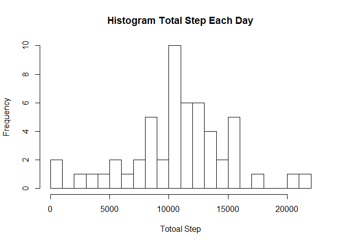

```r
hist(sum_data$total_steps , main = "Histogram Total Step Each Day" , xlab = "Totoal Step", breaks = 20)
```

```r
mean(data$steps , na.rm = 1)
```

```
## [1] 37.3826
```

```r
median(data$steps , na.rm = 1)
```

```
## [1] 0
```

## What is the average daily activity pattern?

**1. Make a time series plot**

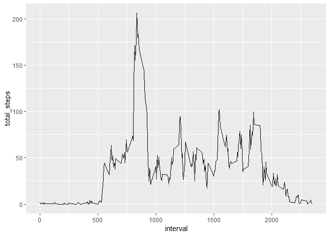

```r
sum_interval <- data%>%
  group_by(interval) %>%
  summarize(total_steps= mean(steps, na.rm = 1))

ggplot(sum_interval, aes(x=interval, y=total_steps))+ geom_line()
```

**2. Which 5-minute interval, on average across all the days in the dataset, contains the maximum number of steps?**

```r
sum_interval[which(sum_interval$total_steps== max(sum_interval$total_steps)),]
```

```
## # A tibble: 1 x 2
##   interval total_steps
##      <int>       <dbl>
## 1      835        206.
```

## Imputing missing values

**1. Calculate and report the total number of missing values in the dataset (i.e. the total number of rows with NAs)**

```r
sum(is.na(data))
```

```
## [1] 2304
```

**2. Devise a strategy for filling in all of the missing values in the dataset** replace Na value with mean for that 5-minute interval

```r
replacewithmean <- function(x) replace(x, is.na(x), mean(x, na.rm = TRUE))
```

**3. Create a new dataset that is equal to the original dataset but with the missing data filled in.**

```r
meandata <- data%>% group_by(interval) %>% mutate(steps= replacewithmean(steps))
head(meandata)
```

```
## # A tibble: 6 x 3
## # Groups:   interval [6]
##    steps date       interval
##    <dbl> <date>        <int>
## 1 1.72   2012-10-01        0
## 2 0.340  2012-10-01        5
## 3 0.132  2012-10-01       10
## 4 0.151  2012-10-01       15
## 5 0.0755 2012-10-01       20
## 6 2.09   2012-10-01       25
```

**4. Make a histogram of the total number of steps taken each day**

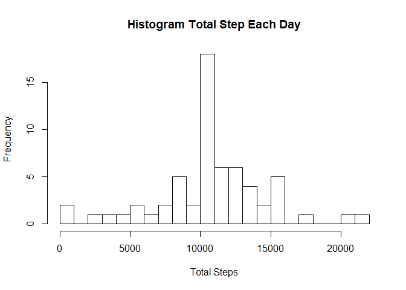

```r
sum_meandata <- meandata %>%
  group_by(date) %>%
  summarise(total_steps = sum(steps),
            mean_steps = mean(steps)            ,
            median_steps = median(steps))

hist(sum_meandata$total_steps , main = "Histogram Total Step Each Day" , xlab = "Total Steps", breaks = 20)
```

## Differences Mean & Median

```r
rbind(mean(data$steps, na.rm = 1,row.names=1) , mean(meandata$steps))
```

```
##         [,1]
## [1,] 37.3826
## [2,] 37.3826
```

```r
rbind(median(data$steps, na.rm = 1,row.names=1) , median(meandata$steps))
```

```
##      [,1]
## [1,]    0
## [2,]    0
```

## Are there differences in activity patterns between weekdays and weekends?

**1. Create a new factor variable in the dataset with two levels – “weekday” and “weekend”**

```r
meandata$weekday <- weekdays(meandata$date)
meandata$weekend <- ifelse(meandata$weekday=="Saturday" | meandata$weekday=="Sunday", "Weekend", "Weekday" )
head(meandata)
```

```
## # A tibble: 6 x 5
## # Groups:   interval [6]
##    steps date       interval weekday weekend
##    <dbl> <date>        <int> <chr>   <chr>
## 1 1.72   2012-10-01        0 Monday  Weekday
## 2 0.340  2012-10-01        5 Monday  Weekday
## 3 0.132  2012-10-01       10 Monday  Weekday
## 4 0.151  2012-10-01       15 Monday  Weekday
## 5 0.0755 2012-10-01       20 Monday  Weekday
## 6 2.09   2012-10-01       25 Monday  Weekday
```

**2. Make a panel plot containing a time series plot (i.e. type = “l”) of the 5-minute interval (x-axis)**

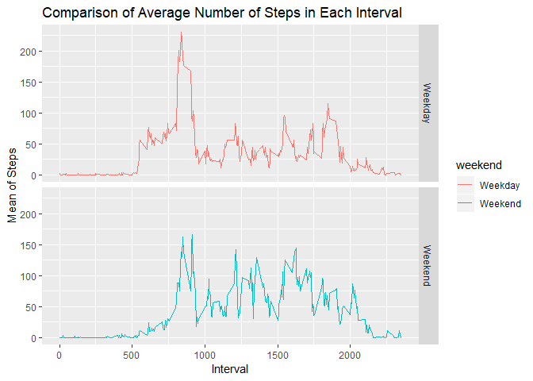

```r
meandataweekendweekday <- aggregate(meandata$steps , by= list(meandata$weekend, meandata$interval), na.omit(mean))
names(meandataweekendweekday) <- c("weekend", "interval", "steps")


ggplot(meandataweekendweekday, aes(x=interval, y=steps, color=weekend)) + geom_line()+
  facet_grid(weekend ~.) + xlab("Interval") + ylab("Mean of Steps") +
  ggtitle("Comparison of Average Number of Steps in Each Interval")
```